# Can rainfall reconstruct missing freshwater exposure?

ERA5 rainfall, wind, IMOS optics, and event-held-out eReefs validation

# Decision rule

Thirty PSU is the primary low-salinity screening threshold. This deliberately increases the number of positive cell-events available for training. Exposure below 28 and 26 PSU remains nested evidence of progressively more severe freshwater conditions; it has not been discarded.

The rainfall model must improve event-held-out average precision and balanced Brier score over the spatial prior, and it must retain useful recall for the below-28-PSU tail. A low all-cell salinity error is not sufficient because ordinary oceanic cells dominate the GBR.

## ERA5 versus ACCESS source choice

[ERA5](https://cds.climate.copernicus.eu/datasets/reanalysis-era5-single-levels) is a consistent hourly reanalysis spanning every event year. The official CDS retrieval API was tested first, but this workstation has no CDS credential and the service requires a logged-in account with its licence accepted. Extraction therefore uses the time-series-optimised layout of the anonymous [AWS Open Data Icechunk ERA5 archive](https://registry.opendata.aws/earthmover-era5/), which is losslessly derived from ECMWF/NCAR source files. A documented ERA5-only mirror was also tested, but it altered rainfall totals in a five-cell check and was rejected rather than mixed with the AWS values.

The Bureau’s publicly documented [ACCESS products](https://www.bom.gov.au/nwp/doc/access/docs/) are operational forecasts rather than a single reanalysis covering all five events. Historical ACCESS archives are available through registered Bureau/NCI services, so ACCESS is not mixed with ERA5 in this first consistent series. It can be added later as an independent 2024 sensitivity if archive access is provided.

# Coverage and class size

Low-salinity sample size under the expanded threshold

| year | eReefs cells | Complete Q1 salinity | Forcing warning | Cells below 30 PSU | Cells below 28 PSU | Minimum salinity |
| --- | --- | --- | --- | --- | --- | --- |
| 2016 | 3707 | TRUE | FALSE | 15 | 9 | 21.49 |
| 2017 | 3707 | TRUE | FALSE | 26 | 16 | 14.03 |
| 2020 | 3707 | TRUE | FALSE | 13 | 2 | 23.59 |
| 2022 | 3707 | TRUE | TRUE | 4 | 3 | 20.95 |
| 2024 | 3707 | FALSE | FALSE | 4 | 3 | 23.41 |

# Rainfall and freshwater exposure

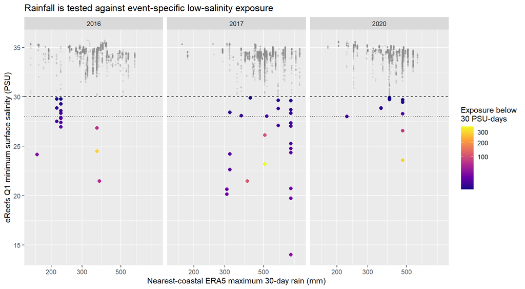

The coastal series is the nearest ERA5 land-cell centre. It is more defensible than rainfall at an offshore reef pixel, but it is still not catchment rainfall, runoff, river discharge, or plume transport. Wind and Kd490 help represent transport and optical plume conditions without changing that limitation.

# Leave-one-event-out occurrence performance

Event-balanced freshwater-occurrence validation

| Model | Average precision <30 | Balanced Brier <30 | Top 1% recall <30 | Top 5% recall <30 | Top 1% recall <28 | Top 5% recall <28 |
| --- | --- | --- | --- | --- | --- | --- |
| Spatial prior | 0.292 | 0.353 | 0.399 | 0.862 | 0.644 | 0.942 |
| Rainfall + optics + wind + spatial | 0.212 | 0.355 | 0.348 | 0.668 | 0.597 | 0.718 |
| Rainfall + spatial | 0.210 | 0.335 | 0.344 | 0.709 | 0.634 | 0.755 |
| Intercept only | 0.005 | 0.495 | 0.038 | 0.277 | 0.042 | 0.227 |

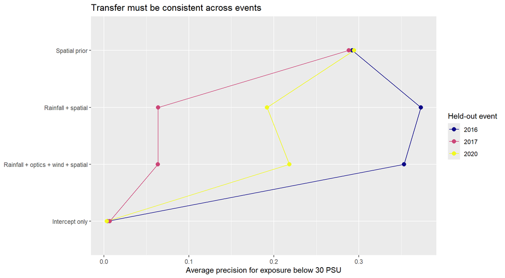

# Minimum-salinity reconstruction

Continuous reconstruction of minimum salinity

| Model | Held-out event | All-cell MAE | Below-30 cell MAE | Below-30 bias | Below-30 detected | Below-28 detected |
| --- | --- | --- | --- | --- | --- | --- |
| Rainfall + optics + wind + spatial | 2016 | 0.338 | 5.931 | 5.931 | 0 | 0 |
| Rainfall + optics + wind + spatial | 2017 | 0.457 | 8.410 | 8.410 | 0 | 0 |
| Rainfall + optics + wind + spatial | 2020 | 0.383 | 3.726 | 3.726 | 0 | 0 |
| Spatial prior | 2016 | 0.352 | 5.890 | 5.890 | 0 | 0 |
| Spatial prior | 2017 | 0.416 | 8.442 | 8.442 | 0 | 0 |
| Spatial prior | 2020 | 0.340 | 3.746 | 3.746 | 0 | 0 |

# 2024 sensitivity layer

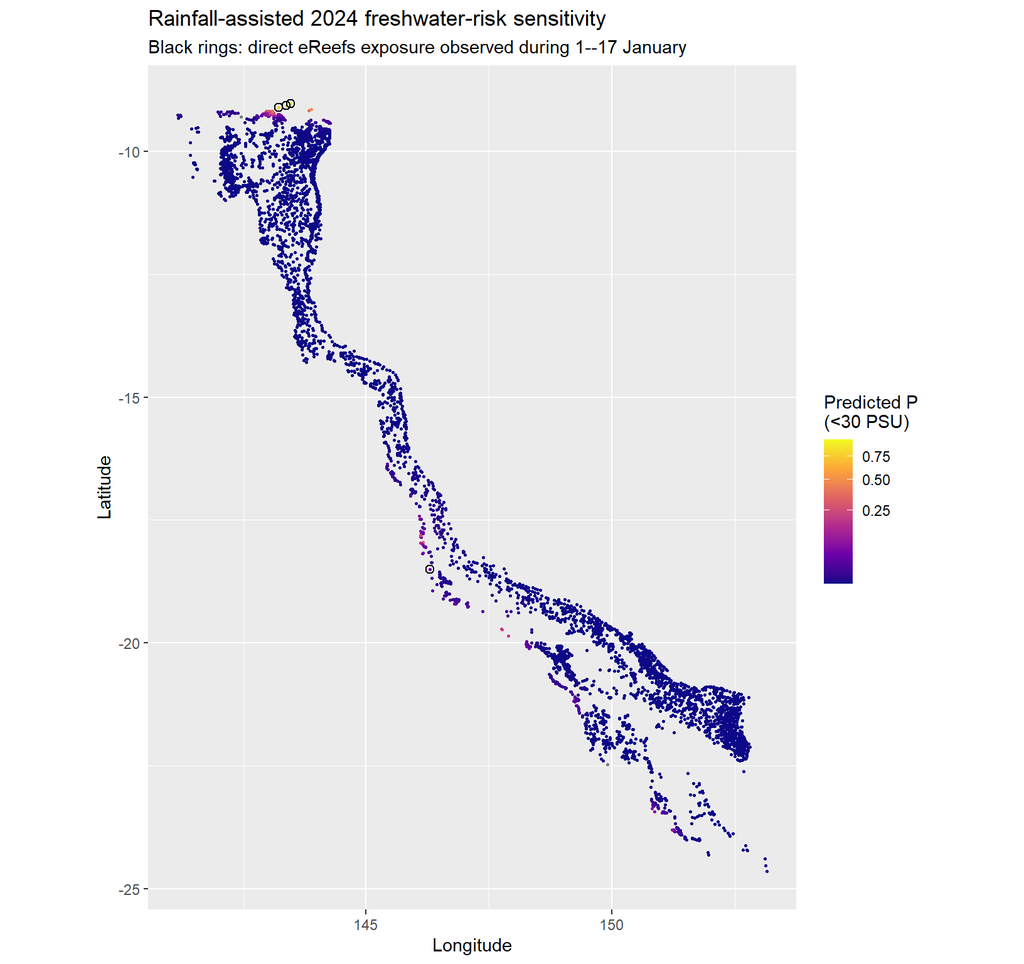

The map remains a sensitivity layer until the event-held-out results above demonstrate improvement over the spatial prior. It is not automatically added to the mortality model, and the partial January 2024 eReefs record is not treated as a full-quarter validation target.